# **Loan Default Prediction**

### **Multivariate Analysis**

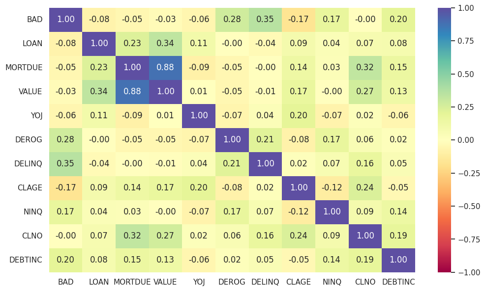

```python
cols_list = df.select_dtypes(include=np.number).columns.tolist()

plt.figure(figsize=(12, 7))
sns.heatmap(df[cols_list].corr(), annot=True, vmin=-1, vmax=1, fmt=".2f", cmap="Spectral")
plt.show()
```

## Treating Missing Values

```python
num_data = df.select_dtypes('number')

cat_data = df.select_dtypes(include=['object', 'category']).columns.tolist()#df.select_dtypes('object')

df[num_data.columns] = num_data.fillna(num_data.median())

for column in cat_data:
    mode = df[column].mode()[0]
    df[column] = df[column].fillna(mode)

df.head()
```

|  | BAD | LOAN | MORTDUE | VALUE | REASON | JOB | YOJ | DEROG | DELINQ | CLAGE | NINQ | CLNO | DEBTINC |
| --- | --- | --- | --- | --- | --- | --- | --- | --- | --- | --- | --- | --- | --- |
| 0 | 1 | 1100 | 25860.0 | 39025.0 | HomeImp | Other | 10.5 | 0.0 | 0.0 | 94.366667 | 1.0 | 9.0 | 34.818262 |
| 1 | 1 | 1300 | 70053.0 | 68400.0 | HomeImp | Other | 7.0 | 0.0 | 2.0 | 121.833333 | 0.0 | 14.0 | 34.818262 |
| 2 | 1 | 1500 | 13500.0 | 16700.0 | HomeImp | Other | 4.0 | 0.0 | 0.0 | 149.466667 | 1.0 | 10.0 | 34.818262 |
| 3 | 1 | 1500 | 65019.0 | 89235.5 | DebtCon | Other | 7.0 | 0.0 | 0.0 | 173.466667 | 1.0 | 20.0 | 34.818262 |
| 4 | 0 | 1700 | 97800.0 | 112000.0 | HomeImp | Office | 3.0 | 0.0 | 0.0 | 93.333333 | 0.0 | 14.0 | 34.818262 |

## **Model Building - Approach**

- Data preparation
- Partition the data into train and test set
- Build the model
- Fit on the train data
- Tune the model
- Test the model on test set

```python
df["BAD"].unique()
```

```
array([1, 0])
```

```python
cat_cols = list(df.select_dtypes("object").columns)
to_get_dummies_for = cat_cols

# Creating dummy variables
df = pd.get_dummies(data = df, columns = to_get_dummies_for, drop_first = True)
df.head()
```

|  | BAD | LOAN | MORTDUE | VALUE | YOJ | DEROG | DELINQ | CLAGE | NINQ | CLNO | DEBTINC | REASON_HomeImp | JOB_Office | JOB_Other | JOB_ProfExe | JOB_Sales | JOB_Self |
| --- | --- | --- | --- | --- | --- | --- | --- | --- | --- | --- | --- | --- | --- | --- | --- | --- | --- |
| 0 | 1 | 1100 | 25860.0 | 39025.0 | 10.5 | 0.0 | 0.0 | 94.366667 | 1.0 | 9.0 | 34.818262 | True | False | True | False | False | False |
| 1 | 1 | 1300 | 70053.0 | 68400.0 | 7.0 | 0.0 | 2.0 | 121.833333 | 0.0 | 14.0 | 34.818262 | True | False | True | False | False | False |
| 2 | 1 | 1500 | 13500.0 | 16700.0 | 4.0 | 0.0 | 0.0 | 149.466667 | 1.0 | 10.0 | 34.818262 | True | False | True | False | False | False |
| 3 | 1 | 1500 | 65019.0 | 89235.5 | 7.0 | 0.0 | 0.0 | 173.466667 | 1.0 | 20.0 | 34.818262 | False | False | True | False | False | False |
| 4 | 0 | 1700 | 97800.0 | 112000.0 | 3.0 | 0.0 | 0.0 | 93.333333 | 0.0 | 14.0 | 34.818262 | True | True | False | False | False | False |

```python
Y = df["BAD"]
X = df.drop(["BAD"], axis=1)

X.head()
```

|  | LOAN | MORTDUE | VALUE | YOJ | DEROG | DELINQ | CLAGE | NINQ | CLNO | DEBTINC | REASON_HomeImp | JOB_Office | JOB_Other | JOB_ProfExe | JOB_Sales | JOB_Self |
| --- | --- | --- | --- | --- | --- | --- | --- | --- | --- | --- | --- | --- | --- | --- | --- | --- |
| 0 | 1100 | 25860.0 | 39025.0 | 10.5 | 0.0 | 0.0 | 94.366667 | 1.0 | 9.0 | 34.818262 | True | False | True | False | False | False |
| 1 | 1300 | 70053.0 | 68400.0 | 7.0 | 0.0 | 2.0 | 121.833333 | 0.0 | 14.0 | 34.818262 | True | False | True | False | False | False |
| 2 | 1500 | 13500.0 | 16700.0 | 4.0 | 0.0 | 0.0 | 149.466667 | 1.0 | 10.0 | 34.818262 | True | False | True | False | False | False |
| 3 | 1500 | 65019.0 | 89235.5 | 7.0 | 0.0 | 0.0 | 173.466667 | 1.0 | 20.0 | 34.818262 | False | False | True | False | False | False |
| 4 | 1700 | 97800.0 | 112000.0 | 3.0 | 0.0 | 0.0 | 93.333333 | 0.0 | 14.0 | 34.818262 | True | True | False | False | False | False |

```python
Y.head()
```

```
0    1
1    1
2    1
3    1
4    0
Name: BAD, dtype: int64
```

```python
x_train, x_test, y_train, y_test = train_test_split(X, Y, test_size=0.30, random_state=1, stratify=Y)
```

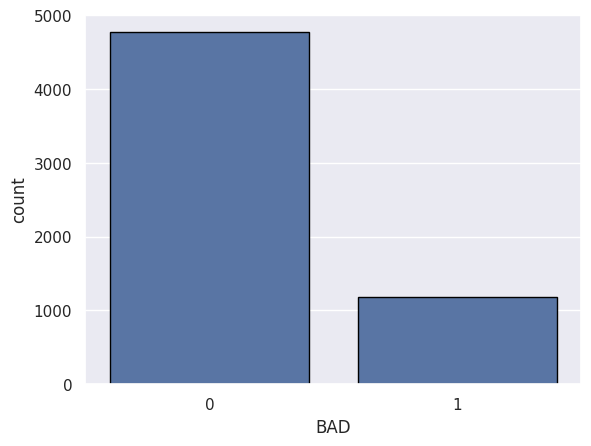

```python
sns.countplot(data=df, x='BAD', edgecolor = "black");
```

```python
pct_label_0 = Y[Y == 0].shape[0] / Y.shape[0]

pct_label_1 = Y[Y == 1].shape[0] / Y.shape[0]

print(f'Percentage of Label 0 (Not Default): {round(pct_label_0*100, 2)}.   Percentage of Label 1 (Default): {round(pct_label_1*100, 2)}')
```

```
Percentage of Label 0 (Not Default): 80.05.   Percentage of Label 1 (Default): 19.95
```

```python
def metrics_score(actual, predicted):

    # Print classification report
    print(classification_report(actual, predicted))

    # Compute confusion matrix
    cm = confusion_matrix(actual, predicted)

    # Plot confusion matrix
    plt.figure(figsize = (8, 5))
    sns.heatmap(cm, annot = True, fmt = '.2f', xticklabels = ['Not Default', 'Default'], yticklabels = ['Not Default', 'Default'])
    plt.ylabel('Actual')

    plt.xlabel('Predicted')

    plt.show()
```

```python
def model_performance_classification(model, predictors, target):
    """
    Function to compute different metrics to check classification model performance

    model: classifier

    predictors: independent variables

    target: dependent variable
    """

    # Predicting using the independent variables
    pred = model.predict(predictors)

    recall = recall_score(target, pred, average = 'macro')          # To compute recall
    precision = precision_score(target, pred, average = 'macro')    # To compute precision
    acc = accuracy_score(target, pred)                              # To compute accuracy score

    # Creating a dataframe of metrics
    df_perf = pd.DataFrame({"Precision": precision,
                            "Recall":  recall,
                            "Accuracy": acc}, index = [0])

    return df_perf
```

### Logistic Regression

```python
logreg = LogisticRegression(random_state=1)
```

```python
logreg.fit(x_train, y_train)
```

```
LogisticRegression(random_state=1)
```

```python
# Predicting the test set results
y_pred_logreg = logreg.predict(x_test)
```

```
              precision    recall  f1-score   support

           0       0.80      1.00      0.89      1431
           1       0.50      0.00      0.01       357

    accuracy                           0.80      1788
   macro avg       0.65      0.50      0.45      1788
weighted avg       0.74      0.80      0.71      1788
```

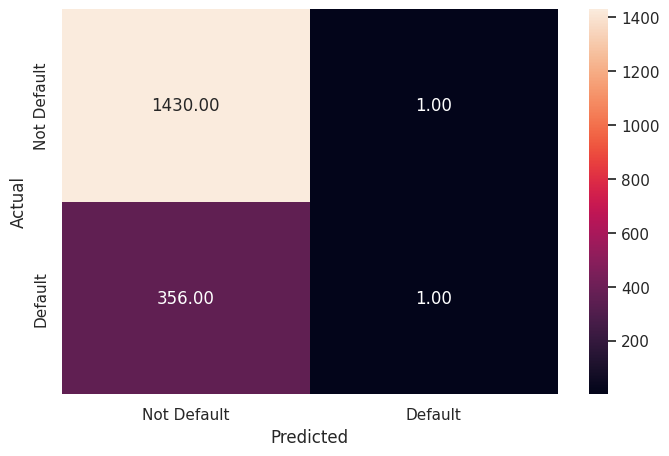

|  | Precision | Recall | Accuracy |
| --- | --- | --- | --- |
| 0 | 0.804214 | 0.774228 | 0.870805 |

```python
# Print the classification report and confusion matrix
metrics_score(y_test, y_pred_logreg)

# Performance of the model
model_performance_classification(logreg, x_test, y_test)
# Performance with test data
logreg_test = model_performance_classification(dt_weights, x_test, y_test)
logreg_test
```

### Decision Tree

```python
## The model can make two types of wrong predictions:

# Predicting an applicant will default when the applicant doesn't default
# Predicting an applicant will not default when the lead actually defaults --> False Positive
# The issues faced by the Loan provider is to identify which of the applicants are more likely to default so that give them a loan --> False negative

#Since the goal is minimize giving loans to customers who are likely to default, we need to reduce False Negatives

#How to reduce False Negatives?

# The company would want the Recall to be maximized, the greater the Recall,
# the higher the chances of minimizing false negatives. Hence,
# the focus should be on increasing the Recall (minimizing the false negatives) or,
# in other words, identifying the true positives
```

### **Decision Tree - Hyperparameter Tuning**

- Hyperparameter tuning is tricky in the sense that **there is no direct way to calculate how a change in the hyperparameter value will reduce the loss of your model**, so we usually resort to experimentation. We'll use Grid search to perform hyperparameter tuning.
- **Grid search is a tuning technique that attempts to compute the optimum values of hyperparameters.**
- **It is an exhaustive search** that is performed on the specific parameter values of a model.
- The parameters of the estimator/model used to apply these methods are **optimized by cross-validated grid-search** over a parameter grid.

**Criterion {“gini”, “entropy”}**

The function to measure the quality of a split. Supported criteria are “gini” for the Gini impurity and “entropy” for the information gain.

**max_depth**

The maximum depth of the tree. If None, then nodes are expanded until all leaves are pure or until all leaves contain less than min_samples_split samples.

**min_samples_leaf**

The minimum number of samples is required to be at a leaf node. A split point at any depth will only be considered if it leaves at least min_samples_leaf training samples in each of the left and right branches. This may have the effect of smoothing the model, especially in regression.

You can learn about more Hyperpapameters on this link and try to tune them.

https://scikit-learn.org/stable/modules/generated/sklearn.tree.DecisionTreeClassifier.html

```python
# Building decision tree model
dt_no_weights = DecisionTreeClassifier(random_state = 1)

dt_weights = DecisionTreeClassifier(class_weight = {0: 0.20, 1: 0.80}, random_state = 1)
```

```python
dt_no_weights.fit(x_train, y_train)
```

```
DecisionTreeClassifier(random_state=1)
```

```python
dt_weights.fit(x_train, y_train)
```

```
DecisionTreeClassifier(class_weight={0: 0.2, 1: 0.8}, random_state=1)
```

```python
#Model Performance and Eval

y_train_pred_dt = dt_weights.predict(x_train)

metrics_score(y_train, y_train_pred_dt)
```

```
              precision    recall  f1-score   support

           0       1.00      1.00      1.00      3340
           1       1.00      1.00      1.00       832

    accuracy                           1.00      4172
   macro avg       1.00      1.00      1.00      4172
weighted avg       1.00      1.00      1.00      4172
```

```
              precision    recall  f1-score   support

           0       0.91      0.94      0.92      1431
           1       0.70      0.61      0.65       357

    accuracy                           0.87      1788
   macro avg       0.80      0.77      0.79      1788
weighted avg       0.87      0.87      0.87      1788
```

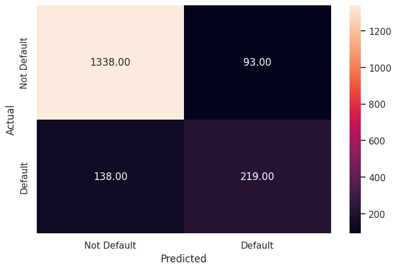

```python
# Checking performance on the test dataset
y_test_pred_dt = dt_weights.predict(x_test)

metrics_score(y_test, y_test_pred_dt)
```

```python
######

# Here the training set gave a Recall of 1 but performed poorly with the test data.

# The model is overfitting
```

```python
model_performance_classification(dt_weights, x_train, y_train)
```

|  | Precision | Recall | Accuracy |
| --- | --- | --- | --- |
| 0 | 1.0 | 1.0 | 1.0 |

```python
model_performance_classification(dt_weights, x_test, y_test)
```

|  | Precision | Recall | Accuracy |
| --- | --- | --- | --- |
| 0 | 0.804214 | 0.774228 | 0.870805 |

```python
# Performance with test data
dtree_test = model_performance_classification(dt_weights, x_test, y_test)
dtree_test
```

|  | Precision | Recall | Accuracy |
| --- | --- | --- | --- |
| 0 | 0.804214 | 0.774228 | 0.870805 |

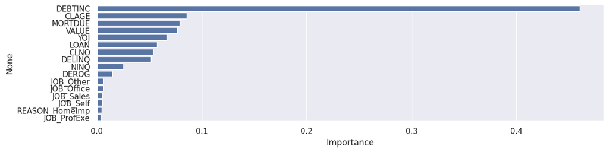

```python
# Feature importance
importances = dt_weights.feature_importances_

# Rename columns
columns = X.columns

# Create a DataFrame with features importance
importance_df = pd.DataFrame(importances, index = columns, columns = ['Importance']).sort_values(by = 'Importance', ascending = False)

# Plot
plt.figure(figsize = (13, 3))
sns.barplot(x=importance_df.Importance,y=importance_df.index);
```

```python
# According to the "Importance" graph, there is more empasis on the debt to income
# ratio, followed by the age of the oldest credit line and the amount of mortgage due
```

```python
#Start Tuning using GridSearch

%%time
# Choose the type of classifier
dtree_tuned = DecisionTreeClassifier(class_weight = {0: 0.20, 1: 0.80}, random_state = 1)

# Grid of parameters to choose from
parameters = {'max_depth': np.arange(2, 7),
              'criterion': ['gini', 'entropy'],
              'min_samples_leaf': [5, 10, 20, 25]}

# Type of scoring used to compare parameter combinations.
# "pos_label": It allows you to specify which class label should be considered as the positive class when calculating the scoring metric.
# By default, pos_label = 1, but you can change it based on your specific use case.
scorer = metrics.make_scorer(precision_score, pos_label = 1)

# Grid search object
gridCV = GridSearchCV(dtree_tuned, parameters, scoring = scorer, cv = 10)

# Fitting the grid search on the train data
gridCV = gridCV.fit(x_train, y_train)

# Set the classifier to the best combination of parameters
dtree_tuned = gridCV.best_estimator_

# Fit the best estimator to the data
dtree_tuned.fit(x_train, y_train)
```

```
CPU times: user 9.37 s, sys: 993 µs, total: 9.37 s
Wall time: 9.43 s
```

```
DecisionTreeClassifier(class_weight={0: 0.2, 1: 0.8}, criterion='entropy',
                       max_depth=3, min_samples_leaf=10, random_state=1)
```

```
              precision    recall  f1-score   support

           0       0.94      0.88      0.91      3340
           1       0.62      0.77      0.68       832

    accuracy                           0.86      4172
   macro avg       0.78      0.83      0.80      4172
weighted avg       0.87      0.86      0.86      4172
```

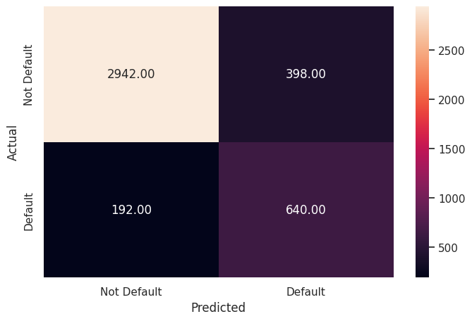

```python
y_train_pred_dt = dtree_tuned.predict(x_train)

metrics_score(y_train, y_train_pred_dt)
```